# Visualization of imaging cytometry data in R

# Introduction

This vignette gives an introduction to displaying highly-multiplexed imaging cytometry data with the `cytomapper` package. As an example, these instructions display imaging mass cytometry (IMC) data. However, other imaging cytometry approaches including multiplexed ion beam imaging (MIBI) (Angelo et al. 2014), tissue-based cyclic immunofluorescence (t-CyCIF) (Lin et al. 2018) and iterative indirect immunofluorescence imaging (4i) (Gut, Herrmann, and Pelkmans 2018), which produce pixel-level intensities and optionally segmentation masks can be displayed using `cytomapper`.

IMC (Giesen et al. 2014) is a multiplexed imaging cytometry approach to measure spatial protein abundance. In IMC, tissue sections are stained with a mix of around 40 metal-conjugated antibodies prior to laser ablation with $1\mu{}m$ resolution. The ablated material is transferred to a mass cytometer for time-of-flight detection of the metal ions [Giesen et al. (2014)](Mavropoulos et al., n.d.). In that way, hundreds of images (usually with an image size of around 1mm x 1mm) can be generated in a reasonable amount of time (Damond et al. 2019).

Raw IMC data are computationally processed using a segmentation pipeline (available at https://github.com/BodenmillerGroup/ImcSegmentationPipeline). This pipeline produces image stacks containing the raw pixel values for up to 40 channels, segmentation masks containing the segmented cells, cell-level expression and metadata information as well as a number of image-level meta information.

Cell-level expression and metadata can be processed and read into a `SingleCellExperiment` class object. For more information on the `SingleCellExperiment` object and how to create it, please see the *SingleCellExperiment* package and the [Orchestrating Single-Cell Analysis with Bioconductor](https://bioconductor.org/books/release/OSCA/data-infrastructure.html) workflow. Furthermore, the `cytomapper` package provides the measureObjects function that generates a `SingleCellExperiment` based on segmentation masks and multi-channel images.

The `cytomapper` package provides a new `CytoImageList` class as a container for multiplexed images or segmentation masks. For more information on this class, refer to the CytoImageList section.

The main functions of this package include `plotCells` and `plotPixels`. The `plotCells` function requires the following object inputs to display cell-level information (expression and metadata):

1. a `SingleCellExperiment` object, which contains the cells’ counts and metadata
2. a `CytoImageList` object containing the segmentation masks

The `plotPixels` function requires the following object inputs to display pixel-level expression information:

1. a `CytoImageList` object containing the pixel-level information per channel
2. (optionally) a `SingleCellExperiment` object, which contains the cells’ counts and metadata
3. (optionally) a `CytoImageList` object containing the segmentation masks

# Quick start

The following section provides a quick example highlighting the functionality of `cytomapper`. For detailed information on reading in the data, refer to the Reading in data section. More information on the required data format is provided in the Data formats section. In the first step, we will read in the provided toy dataset

```r
data(pancreasSCE)
data(pancreasImages)
data(pancreasMasks)
```

The `CytoImageList` object containing pixel-level intensities representing the ion counts for five proteins can be displayed using the `plotPixels` function:

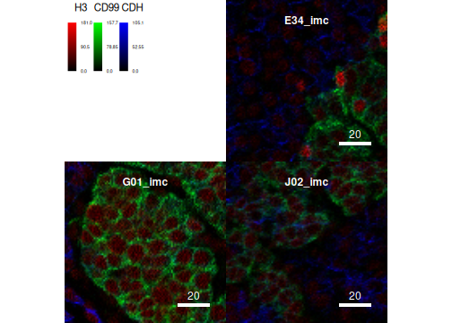

```r
plotPixels(image = pancreasImages, colour_by = c("H3", "CD99", "CDH"))
```

For more details on image normalization, cell outlining, and other pixel-level manipulations, refer to the Plotting pixel information section.

The `CytoImageList` object containing segmentation masks, which represent cell areas on the image can be displayed using the `plotCells` function. Only the segmentation masks are plotted when no other parameters are specified.

To colour and/or outline segmentation masks, a `SingleCellExperiment`, an `img_id` and `cell_id` entry need to be specified:

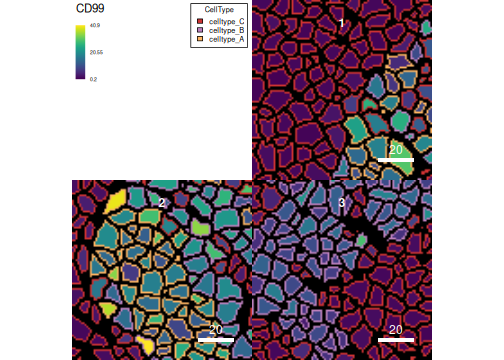

```r
plotCells(mask = pancreasMasks, object = pancreasSCE,
            cell_id = "CellNb", img_id = "ImageNb", colour_by = "CD99",
            outline_by = "CellType")
```

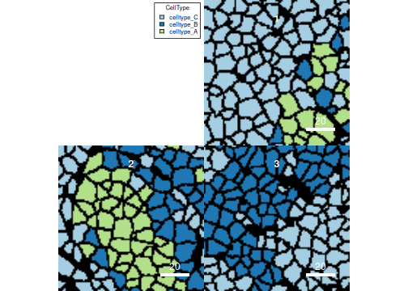

```r
plotCells(mask = pancreasMasks, object = pancreasSCE,
            cell_id = "CellNb", img_id = "ImageNb",
            colour_by = "CellType")
```

For more information on the data formats and requirements, refer to the following section. More details on the `plotCells` function are provided in the Plotting cell information section. Also refer to the measureObjects function to generate a `SingleCellExperiment` directly from the images.

# Data formats

The `cytomapper` package combines objects of the *SingleCellExperiment* class and the `CytoImageList` class (provided in `cytomapper`) to visualize cell- and pixel-level information.

In the main functions of the package, `image` refers to a `CytoImageList` object containing one or multiple multi-channel images where each channel represents the pixel-intensity of one selected marker (proteins in the case of IMC). The entry `mask` refers to a `CytoImageList` object containing one or multiple segmentation masks. Segmentation masks are defined as one-channel images containing integer values, which represent the cells’ ids or 0 (background). Finally, the `object` entry refers to a `SingleCellExperiment` class object that contains cell-specific expression values (in the `assay` slots) and cell-specific metadata in the `colData` slot.

To link information between the `SingleCellExperiment` and `CytoImageList` objects, two slots need to be specified:

- `img_id`: a single character indicating the `colData` (in the `SingleCellExperiment` object) and `elementMetadata` (in the `CytoImageList` object) entry that contains the image identifiers. These image ids have to match between the `SingleCellExperiment` object and the `CytoImageList` object.
- `cell_id`: a single character indicating the `colData` entry that contains the cell identifiers. These should be integer values corresponding to pixel-values in the segmentation masks.

The `img_id` and `cell_id` entry in the `SingleCellExperiment` object need to be accessible via:

```r
head(colData(pancreasSCE)[,"ImageNb"])
```

```
## [1] 1 1 1 1 1 1
```

```r
head(colData(pancreasSCE)[,"CellNb"])
```

```
## [1] 824 835 839 844 847 853
```

The `img_id` entry in the `CytoImageList` object need to be accessible via:

```r
mcols(pancreasImages)[,"ImageNb"]
```

```
## [1] 1 2 3
```

```r
mcols(pancreasMasks)[,"ImageNb"]
```

```
## [1] 1 2 3
```

For more information on the `CytoImageList` class, please refer to the section The CytoImageList object. For more information on the `SingleCellExperiment` object and how to create it, please see the *SingleCellExperiment* package and the [Orchestrating Single-Cell Analysis with Bioconductor](https://osca.bioconductor.org/data-infrastructure.html#the-singlecellexperiment-class) workflow.

## The provided toy dataset

For visualization purposes, the `cytomapper` package provides a toy dataset containing 3 images of $100\mu{m}$ x $100\mu{m}$ dimensions (100 x 100 pixels). The dataset contains 362 segmented cells and the expression values for 5 proteins: H3, CD99, PIN, CD8a, and CDH It represents a small subset of the data presented in A Map of Human Type 1 Diabetes Progression by Imaging Mass Cytometry.

This dataset was generated using imaging mass cytometry (Giesen et al. 2014). Raw output files (in .mcd format) were processed using the [IMC segmentation pipeline](https://github.com/BodenmillerGroup/ImcSegmentationPipeline), which produces tiff-stacks containing the pixel-level information of all measured markers, segmentation masks that contain the cells’ object ids as well as cell- and image-specific measurements. Cell-specific measurements include the mean marker intensity per cell and per marker, the cells’ position and size measurements.

Pixel-level intensities for all 5 markers (5 channels) are stored in the `pancreasImages` object. Entries to the `CytoImageList` object and the rownames of `elementMetadata` match: E34_imc, G01_imc, and J02_imc. The `elementMetadata` slot (accesible via the `mcols()` function) contains the image identifiers.

```r
pancreasImages
```

```
## CytoImageList containing 3 image(s)
## names(3): E34_imc G01_imc J02_imc
## Each image contains 5 channel(s)
## channelNames(5): H3 CD99 PIN CD8a CDH
```

```r
mcols(pancreasImages)
```

```
## DataFrame with 3 rows and 2 columns
##           ImageName   ImageNb
##         <character> <integer>
## E34_imc         E34         1
## G01_imc         G01         2
## J02_imc         J02         3
```

```r
channelNames(pancreasImages)
```

```
## [1] "H3"   "CD99" "PIN"  "CD8a" "CDH"
```

```r
imageData(pancreasImages[[1]])[1:15,1:5,1]
```

```
##               [,1]      [,2]         [,3]         [,4]         [,5]
##  [1,] 2.235787e+00 0.2537275 1.269632e+00 9.991982e-01 1.990020e+00
##  [2,] 2.885528e+00 1.9900196 2.264642e+00 0.000000e+00 1.410924e+00
##  [3,] 3.400943e+00 0.9950098 9.950098e-01 2.180066e+00 4.152935e-17
##  [4,] 3.223832e+00 3.1750760 1.128341e+00 4.486604e+00 7.371460e-16
##  [5,] 9.987666e-01 1.9900196 2.644036e-15 0.000000e+00 0.000000e+00
##  [6,] 7.094598e-17 2.9412489 2.985029e+00 1.990020e+00 9.950098e-01
##  [7,] 2.149031e-16 0.0000000 9.950098e-01 5.537247e-16 0.000000e+00
##  [8,] 3.936259e+00 0.0000000 4.269442e-15 1.240777e+00 2.630806e+00
##  [9,] 9.987666e-01 1.6437560 3.625816e+00 0.000000e+00 2.123351e+00
## [10,] 1.401616e-16 1.9900196 2.941249e+00 3.090500e+00 0.000000e+00
## [11,] 1.382069e+00 3.0258245 4.481710e-16 0.000000e+00 1.946239e+00
## [12,] 4.239594e+00 2.7720971 9.136457e-16 4.677541e+00 4.118345e+00
## [13,] 2.687521e+00 0.0000000 5.149176e+00 9.988809e-01 4.677541e+00
## [14,] 4.513364e+00 1.4666444 9.950098e-01 2.828813e+00 2.772097e+00
## [15,] 1.999239e+00 2.4616542 3.999584e+00 1.484527e+01 1.225784e+01
```

The corresponding segmentation masks are stored in the `pancreasMasks` object and can be read in from tiff images containing the segmentation masks (see next section). Segmentation masks are defined as one-channel images containing integer values, which represent the cells’ ids or 0 (background).

```r
pancreasMasks
```

```
## CytoImageList containing 3 image(s)
## names(3): E34_mask G01_mask J02_mask
## Each image contains 1 channel
```

```r
mcols(pancreasMasks)
```

```
## DataFrame with 3 rows and 2 columns
##            ImageName   ImageNb
##          <character> <integer>
## E34_mask         E34         1
## G01_mask         G01         2
## J02_mask         J02         3
```

```r
imageData(pancreasMasks[[1]])[1:15,1:5]
```

```
##       [,1] [,2] [,3] [,4] [,5]
##  [1,]  824  824  824  824    0
##  [2,]  824  824  824  824    0
##  [3,]  824  824  824  824    0
##  [4,]  824  824  824  824  824
##  [5,]  824  824  824  824  824
##  [6,]  824  824  824  824  824
##  [7,]  824  824  824  824  824
##  [8,]  824  824  824  824  824
##  [9,]  824  824  824  824  824
## [10,]  824  824  824  824    0
## [11,]  824  824  824    0    0
## [12,]  824  824    0    0    0
## [13,]    0    0    0    0  864
## [14,]    0    0    0  864  864
## [15,]    0  864  864  864  864
```

The IMC segmentation pipeline also generates cell-specific measurements. The `SingleCellExperiment` class offers an ideal container to store cell-specific expression counts together with cell-specific metadata. For the toy dataset, cell-specific mean marker intensities (`counts`) and arcsinh-transformed mean marker intensities (`exprs`) are stored in the `assays(pancreasSCE)` slot. All cell-specific metadata are stored in the `colData` slot of the corresponding `SingleCellExperiment` object: `pancreasSCE`. For more information on the metadata, please refer to the `?pancreasSCE` documentation. Of note: the cell-type labels contained in the `colData(pancreasSCE)$CellType` slot are arbitrary and only partly represent biologically relevant cell-types.

```r
pancreasSCE
```

```
## class: SingleCellExperiment
## dim: 5 362
## metadata(0):
## assays(2): counts exprs
## rownames(5): H3 CD99 PIN CD8a CDH
## rowData names(4): MetalTag Target clean_Target frame
## colnames(362): E34_824 E34_835 ... J02_4190 J02_4209
## colData names(9): ImageName Pos_X ... MaskName Pattern
## reducedDimNames(0):
## mainExpName: NULL
## altExpNames(0):
```

```r
names(colData(pancreasSCE))
```

```
## [1] "ImageName" "Pos_X"     "Pos_Y"     "Area"      "CellType"  "ImageNb"
## [7] "CellNb"    "MaskName"  "Pattern"
```

The `pancreasSCE` object also contains further information on the measured proteins via the `rowData(pancreasSCE)` slot. Furthermore, the `pancreasSCE` object contains the raw expression counts per cell in the form of mean pixel value per cell and protein (accessible via `counts(pancreasSCE)`). The arcsinh-transformed (using a co-factor of 1) raw expression counts can be obtained via `assay(pancreasSCE, "exprs")`.

For more information on how to generate `SingleCellExperiment` objects from count-based data, see [Orchestrating Single-Cell Analysis with Bioconductor](https://osca.bioconductor.org/data-infrastructure.html#the-singlecellexperiment-class).

# Reading in data

The `cytomapper` package provides the `loadImages` function to conveniently read images into a `CytoImageList` object.

## Load images

The `loadImages` function returns a `CytoImageList` object containing the multi-channel images or segmentation masks. Refer to the `?loadImages` function to see the full functionality.

As an example, we will read in multi-channel images and segmentation masks provided by the `cytomapper` package.

```r
# Read in masks
path.to.images <- system.file("extdata", package = "cytomapper")
all_masks <- loadImages(path.to.images, pattern = "_mask.tiff")
all_masks
```

```
## CytoImageList containing 3 image(s)
## names(3): E34_mask G01_mask J02_mask
## Each image contains 1 channel
```

```r
# Read in images
all_stacks <- loadImages(path.to.images, pattern = "_imc.tiff")
all_stacks
```

```
## CytoImageList containing 3 image(s)
## names(3): E34_imc G01_imc J02_imc
## Each image contains 5 channel(s)
```

## Add metadata

To link images between the two `CytoImageList` objects and the corresponding `SingleCellExperiment` object, the image ids need to be added to the `elementMetadata` slot of the `CytoImageList` objects. From the experimental setup, we know that the image named ‘E34_imc’ has image id ‘1’, G01_imc has id ‘2’, J02_imc has id ‘3’.

```r
unique(pancreasSCE$ImageNb)
```

```
## [1] 1 2 3
```

```r
mcols(all_masks)$ImageNb <- c("1", "2", "3")
mcols(all_stacks)$ImageNb <- c("1", "2", "3")
```

## Scale images

We can see that, in some cases, the pixel-values are not correctly scaled by the image encoding. The segmentation masks should only contain integer entries:

```r
head(unique(as.numeric(all_masks[[1]])))
```

```
## [1] 0.01257343 0.00000000 0.01318379 0.01310750 0.01287861 0.01280232
```

The provided data was processed using CellProfiler (Carpenter et al. 2006). By default, CellProfiler scales all pixel intensities between 0 and 1. This is done by dividing each count by the maximum possible intensity value (see [MeasureObjectIntensity](https://cellprofiler-manual.s3.amazonaws.com/CellProfiler-3.0.0/modules/measurement.html#measureobjectintensity) for more info). In the case of 16-bit encoding (where 0 is a valid intensity), this scaling value is `2^16-1 = 65535`. Therefore, pixel-intensites need to be rescaled by this value. However, this scaling value can change and different images can be scaled by different factors. The user needs make sure to select the correct factors in more complex cases.

The `cytomapper` package provides a `?scaleImages` function. The user needs to manually scale images to obtain the correct pixel-values. Here, we scale the segmentation masks by the factor for 16-bit encoding: `2^16-1`

```r
all_masks <- scaleImages(all_masks, 2^16-1)
head(unique(as.numeric(all_masks[[1]])))
```

```
## [1] 824   0 864 859 844 839
```

Alternatively, the `as.is` parameter can be set to `TRUE` to attempt image scaling while reading in the images:

```r
all_masks_2 <- loadImages(path.to.images, pattern = "_mask.tiff", as.is = TRUE)
head(unique(as.numeric(all_masks_2[[1]])))
```

```
## [1] 824   0 864 859 844 839
```

However, care needs to be taken and masks and images need to be checked if they are correctly imported.

For this toy dataset, the multi-channel images are not affected by this scaling factor. The final `all_masks` object corresponds to the `pancreasMasks` object provided by `cytomapper`.

## Add channel names

To access the correct images in the multi-channel `CytoImageList` object, the user needs to set the correct channel names. For this, the `cytomapper` package provides the `?channelNames` getter and setter function:

```r
channelNames(all_stacks) <- c("H3", "CD99", "PIN", "CD8a", "CDH")
```

The read-in data can now be used for visualization as explained in the Quick start section.

## Generating the SingleCellExperiment object

Based on the processed segmentation masks and multi-channel images, `cytomapper` can be used to measure cell-specific intensities and morphological features. These features are stored in form of a `SingleCellExperiment` object:

```r
sce <- measureObjects(all_masks, all_stacks, img_id = "ImageNb")
sce
```

```
## class: SingleCellExperiment
## dim: 5 362
## metadata(0):
## assays(1): counts
## rownames(5): H3 CD99 PIN CD8a CDH
## rowData names(0):
## colnames: NULL
## colData names(8): ImageNb object_id ... m.majoraxis m.eccentricity
## reducedDimNames(0):
## mainExpName: NULL
## altExpNames(0):
```

By default, the mean intensities per cell and channel are stored in `counts(sce)` while all other morphological features are stored in `colData(sce)`:

```r
counts(sce)[1:5, 1:5]
```

```
##             [,1]       [,2]        [,3]       [,4]       [,5]
## H3    1.50068681 12.7160872  2.16352437  4.6660460  3.4569734
## CD99  1.30339721  0.7676006  2.48035219  1.4353548  0.8031506
## PIN   0.03636109  0.3255984  0.07762631  0.1730306  0.2478255
## CD8a  0.20264913  0.0000000  0.28294494  0.5511711  0.1217455
## CDH  11.42480015  3.8496665 19.80123812 13.1796503 11.7225806
```

```r
colData(sce)
```

```
## DataFrame with 362 rows and 8 columns
##         ImageNb object_id    s.area s.radius.mean      m.cx      m.cy
##     <character> <numeric> <numeric>     <numeric> <numeric> <numeric>
## 1             1       824        55       3.93042   6.21818   2.96364
## 2             1       835         9       1.67054  94.44444   1.22222
## 3             1       839        17       2.47994  46.23529   1.70588
## 4             1       844        13       2.31966  33.92308   1.30769
## 5             1       847        87       4.92717  83.41379   4.66667
## ...         ...       ...       ...           ...       ...       ...
## 358           3      4165        10       1.34998   35.3000   99.0000
## 359           3      4167        34       3.09718   52.0882   98.7647
## 360           3      4173         1       0.00000    1.0000  100.0000
## 361           3      4190         2       0.50000   21.5000  100.0000
## 362           3      4209        12       1.60132   79.5000   99.3333
##     m.majoraxis m.eccentricity
##       <numeric>      <numeric>
## 1      12.17659       0.863513
## 2       8.28709       0.985034
## 3      10.59886       0.977839
## 4      11.03438       0.985930
## 5      13.14283       0.570827
## ...         ...            ...
## 358     4.08496       0.514302
## 359    11.07958       0.932569
## 360     0.00000       0.000000
## 361     2.00000       1.000000
## 362     5.53775       0.842701
```

# The CytoImageList object

The `cytomapper` package provides a new `CytoImageList` class, which inherits from the [`SimpleList` class](https://rdrr.io/bioc/S4Vectors/man/SimpleList-class.html). Each entry to the `CytoImageList` object is an `Image` class object defined in the *EBImage* package. A `CytoImageList` object is restricted to the following entries:

- all images need to have the same number of channels
- the order/naming of channels need to be the same across all images
- entries to the `CytoImageList` object need to be uniquely named
- names of `CytoImageList` object can either be `NULL` or should not contain `NA` or empty entries
- only grayscale images are supported (see `?Image` for more information)
- channels names do not support duplicated entries

`CytoImageList` objects that contain masks should only contain a single channel

The following paragraphs will explain further details on manipulating `CytoImageList` objects

## Accessors

All accessor functions defined for `SimpleList` also work on `CytoImageList` class objects. Element-wise metadata — in the case of the `CytoImageList` object these are image-specific metadata — are saved in the `elementMetadata` slot. This slot can be accessed via the `mcols()` function:

```r
mcols(pancreasImages)
```

```
## DataFrame with 3 rows and 2 columns
##           ImageName   ImageNb
##         <character> <integer>
## E34_imc         E34         1
## G01_imc         G01         2
## J02_imc         J02         3
```

```r
mcols(pancreasImages)$PatientID <- c("Patient1", "Patient2", "Patient3")
mcols(pancreasImages)
```

```
## DataFrame with 3 rows and 3 columns
##           ImageName   ImageNb   PatientID
##         <character> <integer> <character>
## E34_imc         E34         1    Patient1
## G01_imc         G01         2    Patient2
## J02_imc         J02         3    Patient3
```

Subsetting a `CytoImageList` object works similar to a `SimpleList` object:

```r
pancreasImages[1]
```

```
## CytoImageList containing 1 image(s)
## names(1): E34_imc
## Each image contains 5 channel(s)
## channelNames(5): H3 CD99 PIN CD8a CDH
```

```r
pancreasImages[[1]]
```

```
## Image
##   colorMode    : Grayscale
##   storage.mode : double
##   dim          : 100 100 5
##   frames.total : 5
##   frames.render: 5
##
## imageData(object)[1:5,1:6,1]
##           [,1]      [,2]         [,3]      [,4]         [,5]         [,6]
## [1,] 2.2357869 0.2537275 1.269632e+00 0.9991982 1.990020e+00 0.000000e+00
## [2,] 2.8855283 1.9900196 2.264642e+00 0.0000000 1.410924e+00 5.654589e-16
## [3,] 3.4009433 0.9950098 9.950098e-01 2.1800663 4.152935e-17 1.990020e+00
## [4,] 3.2238317 3.1750760 1.128341e+00 4.4866042 7.371460e-16 0.000000e+00
## [5,] 0.9987666 1.9900196 2.644036e-15 0.0000000 0.000000e+00 1.523360e+00
```

However, to facilitate subsetting and making sure that entry names are transfered between objects, the `cytomapper` package provides a number of getter and setter functions:

### Getting and setting images

Individual or multiple entries in a `CytoImageList` object can be obtained or replaced using the `getImages` and `setImages` functions, respectively.

```r
cur_image <- getImages(pancreasImages, "E34_imc")
cur_image
```

```
## CytoImageList containing 1 image(s)
## names(1): E34_imc
## Each image contains 5 channel(s)
## channelNames(5): H3 CD99 PIN CD8a CDH
```

```r
setImages(pancreasImages, "New_image") <- cur_image
pancreasImages
```

```
## CytoImageList containing 4 image(s)
## names(4): E34_imc G01_imc J02_imc New_image
## Each image contains 5 channel(s)
## channelNames(5): H3 CD99 PIN CD8a CDH
```

```r
mcols(pancreasImages)
```

```
## DataFrame with 4 rows and 3 columns
##             ImageName   ImageNb   PatientID
##           <character> <integer> <character>
## E34_imc           E34         1    Patient1
## G01_imc           G01         2    Patient2
## J02_imc           J02         3    Patient3
## New_image         E34         1    Patient1
```

The `setImages` function ensures that names are transfered from one to the other object along the assignment operator:

```r
names(cur_image) <- "Replacement"
setImages(pancreasImages, 2) <- cur_image
pancreasImages
```

```
## CytoImageList containing 4 image(s)
## names(4): E34_imc Replacement J02_imc New_image
## Each image contains 5 channel(s)
## channelNames(5): H3 CD99 PIN CD8a CDH
```

```r
mcols(pancreasImages)
```

```
## DataFrame with 4 rows and 3 columns
##               ImageName   ImageNb   PatientID
##             <character> <integer> <character>
## E34_imc             E34         1    Patient1
## Replacement         E34         1    Patient1
## J02_imc             J02         3    Patient3
## New_image           E34         1    Patient1
```

However, if the image to replace is called by name, only the image and associated metadata is replaced:

```r
setImages(pancreasImages, "J02_imc") <- cur_image
pancreasImages
```

```
## CytoImageList containing 4 image(s)
## names(4): E34_imc Replacement J02_imc New_image
## Each image contains 5 channel(s)
## channelNames(5): H3 CD99 PIN CD8a CDH
```

```r
mcols(pancreasImages)
```

```
## DataFrame with 4 rows and 3 columns
##               ImageName   ImageNb   PatientID
##             <character> <integer> <character>
## E34_imc             E34         1    Patient1
## Replacement         E34         1    Patient1
## J02_imc             E34         1    Patient1
## New_image           E34         1    Patient1
```

Images can be deleted by setting the entry to `NULL`:

```r
setImages(pancreasImages, c("Replacement", "New_image")) <- NULL
pancreasImages
```

```
## CytoImageList containing 2 image(s)
## names(2): E34_imc J02_imc
## Each image contains 5 channel(s)
## channelNames(5): H3 CD99 PIN CD8a CDH
```

**Of note:** for plotting, the entries in the `img_id` slot in the `CytoImageList` objects have to be unique.

### Getting and setting channels

The `cytomapper` package also provides functions to obtain and replace channels. This functionality is provided via the `getChannels` and `setChannels` functions:

```r
cur_channel <- getChannels(pancreasImages, "H3")
cur_channel
```

```
## CytoImageList containing 2 image(s)
## names(2): E34_imc J02_imc
## Each image contains 1 channel(s)
## channelNames(1): H3
```

```r
channelNames(cur_channel) <- "New_H3"
setChannels(pancreasImages, 1) <- cur_channel
pancreasImages
```

```
## CytoImageList containing 2 image(s)
## names(2): E34_imc J02_imc
## Each image contains 5 channel(s)
## channelNames(5): New_H3 CD99 PIN CD8a CDH
```

The `setChannels` function does not allow combining and adding new channels. For this task, the `cytomapper` package provides the `mergeChannels` section in the next paragraph.

### Naming and merging channels

Channel names can be obtained and replaced using the `channelNames` getter and setter function:

```r
channelNames(pancreasImages)
```

```
## [1] "New_H3" "CD99"   "PIN"    "CD8a"   "CDH"
```

```r
channelNames(pancreasImages) <- c("ch1", "ch2", "ch3", "ch4", "ch5")
pancreasImages
```

```
## CytoImageList containing 2 image(s)
## names(2): E34_imc J02_imc
## Each image contains 5 channel(s)
## channelNames(5): ch1 ch2 ch3 ch4 ch5
```

Furthermore, channels can be merged using the `mergeChannels` function:

```r
cur_channels <- getChannels(pancreasImages, 1:2)
channelNames(cur_channels) <- c("new_ch1", "new_ch2")
pancreasImages <- mergeChannels(pancreasImages, cur_channels)
pancreasImages
```

```
## CytoImageList containing 2 image(s)
## names(2): E34_imc J02_imc
## Each image contains 7 channel(s)
## channelNames(7): ch1 ch2 ch3 ch4 ch5 new_ch1 new_ch2
```

## Looping

To perform custom operations on each individual entry to a `CytoImageList` object, the *S4Vectors* package provides the `endoapply` function. While the `lapply` function returns a `list` object, the `endoapply` function provides an object of the same class of the input object.

This allows the user to apply all functions provided by the *EBImage* package to individual entries within the `CytoImageList` object:

```r
data("pancreasImages")

# Performing a gaussian blur
pancreasImages <- endoapply(pancreasImages, gblur, sigma = 1)
```

# Plotting pixel information

The `cytomapper` package provides the `plotPixels` function to plot pixel-level intensities of marker proteins. The function requires a `CytoImageList` object containing a single or multiple multi-channel images. To colour images based on channel name, the `channelNames` of the object need to be set. Furthermore, to outline cells, a `CytoImageList` object containing segmentation masks and a `SingleCellExperiment` object containing cell-specific metadata need to be provided.

By default, pixel values are coloured internally and scaled between the minimum and maximum values across all displayed images. However, to manipulate pixel values and to linearly scale values to a certain range, the `cytomapper` package provides a function for image normalization.

## Normalization

The `normalize` function provided in the `cytomapper` package internally calls the `normalize` function of the *EBImage* package. The main difference between the two functions is the option to scale per image or globally in the `cytomapper` package (see `?'normalize,CytoImageList-method'`).

By default, the `normalize` function linearly scales the images channel-wise across all images and returns values between 0 and 1 (or the chosen `ft` range):

```r
data("pancreasImages")

# Default normalization
cur_images <- normalize(pancreasImages)
```

A `CytoImageList` object can also be normalized image-wise:

```r
# Image-wise normalization
cur_images <- normalize(pancreasImages, separateImages = TRUE)
```

To clip the image range, the user can provide a clipping range for all channels.

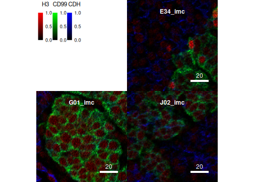

```r
# Percentage-based clipping range
cur_images <- normalize(pancreasImages)
cur_images <- normalize(cur_images, inputRange = c(0, 0.9))
plotPixels(cur_images, colour_by = c("H3", "CD99", "CDH"))
```

Alternatively, channel-specific clipping can be performed:

```r
# Channel-wise clipping
cur_images <- normalize(pancreasImages,
                        inputRange = list(H3 = c(0, 70), CD99 = c(0, 100)))
```

For more information on the normalization functionality provided by the `cytomapper` package, please refer to `?'normalize,CytoImageList-method'`.

## Colouring

The `cytomapper` package supports the visualization of up to 6 channels and displays a combined image by setting the `colour_by` parameter. See `?plotPixels` for examples.

## Adjusting brightness, contrast and gamma

To enhance individual channels, the brightness (b), contrast (c) and gamma (g) can be set channel-wise via the `bcg` parameter. These parameters are set in form of a named `list` object. Entry names need to correspond by channels specified in `colour_by`. Each entry takes a numeric vector of length three where the first entry represents the brightness value, the second the contrast factor and the third the gamma factor. Internally, the brightness value is added to each channel; each channel is multiplied by the contrast factor and each channel is exponentiated by the gamma factor.

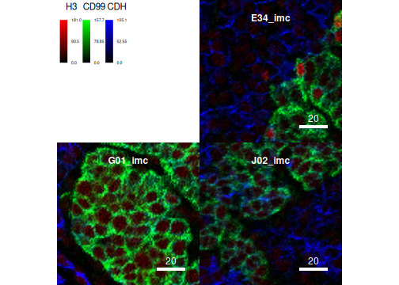

```r
data("pancreasImages")
# Increase contrast for the CD99 and CDH channel
plotPixels(pancreasImages,
            colour_by = c("H3", "CD99", "CDH"),
            bcg = list(CD99 = c(0,2,1),
                        CDH = c(0,2,1)))
```

## Outlining

The cells can be outlined when providing a `CytoImageList` object containing the corresponding segmentation masks and a character `img_id` indicating the name of the `elementMetadata` slot that contains the image IDs.

The user can furthermore specify the metadata entry to outline cells by. For this, a `SingleCellExperiment` object containing the cell-specific metadata and a `cell_id` indicating the name of the `colData` slot that contains the cell IDs need to be provided:

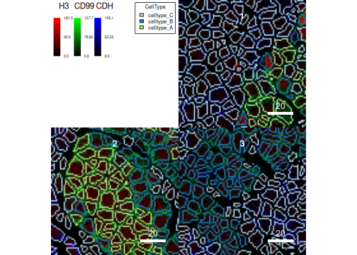

```r
plotPixels(pancreasImages, mask = pancreasMasks,
            object = pancreasSCE, img_id = "ImageNb",
            cell_id = "CellNb",
            colour_by = c("H3", "CD99", "CDH"),
            outline_by = "CellType")
```

## Subsetting

The user can subset the images before calling the plotting functions:

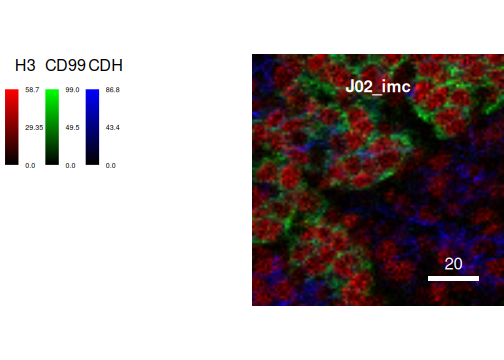

```r
cur_images <- getImages(pancreasImages, "J02_imc")
plotPixels(cur_images, colour_by = c("H3", "CD99", "CDH"))
```

For further information on subsetting functionality, please refer to the Accessors section.

## Adjusting the colour

The user can also customize the colours for selected features. The `colour` parameter takes a named `list` in which names correspond to the entries to `colour_by`. To colour continous features such as expression or continous metadata entries (e.g. cell area, see next section), at least two colours for interpolation need to be provided. These colours are passed to the `colorRampPalette` function for interpolation. For details, please refer to the next Adjusting the colour section

# Plotting cell information

In the following sections, the `plotCells` function will be introduced. This function displays cell-level information on segmentation masks. It requires a `CytoImageList` object containing segmentation masks in the form of single-channel images. Furthermore, to colour and outline cells, a `SingleCellExperiment` object containing cell-specific expression counts and metadata needs to be provided.

By default, cell-specific expression values are coloured internally and scaled marker-specifically between the minimum and maximum values across the full `SingleCellExperiment`.

## Colouring

Segmentation masks can be coloured based on the pixel-values averaged across the area of each cell. In the `SingleCellExperiment` object, these values can be obtained from the `counts()` slot. To colour segmentation masks based on expression, the `rownames` of the `SingleCellExperiment` must be correctly named. The `cytomapper` package supports the visualization of up to 6 channels and displays a combined image. However, in the case of displaying expression on segmentation mask, the user should not display too many features. See `?plotCells` for examples.

## Changing the assay slot

To visualize differently transformed counts, the `plotCells` function allows setting the `exprs_values` parameter. In the toy dataset, the `assay(pancreasSCE, "exprs")` slot contains the arcsinh-transformed raw expression counts.

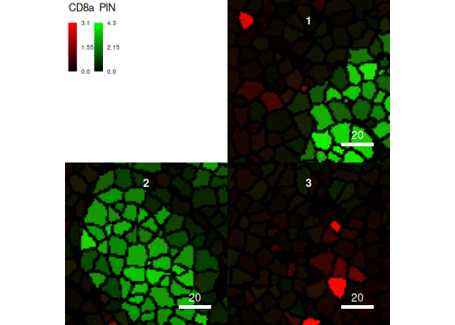

```r
plotCells(pancreasMasks, object = pancreasSCE,
            img_id = "ImageNb", cell_id = "CellNb",
            colour_by = c("CD8a", "PIN"),
            exprs_values = "exprs")
```

## Outlining

The user can furthermore outline cells and specify the metadata entry to outline cells by. See the previous Outlining section and `?plotCells` for examples.

## Subsetting

Similar to the `plotPixels` function, the user can subset the images before plotting. For an example, please see the previous Subsetting section and the Accessors section.

## Adjusting the colour

The user can also customize the colours for selected features and metadata. The `colour` parameter takes a named `list` in which names correspond to the entries to `colour_by` and/or `outline_by`. To colour continous features such as expression or continous metadata entries (e.g. cell area), at least two colours for interpolation need to be provided. These colours are passed to the `colorRampPalette` function for interpolation. To colour discrete entries, one colour per entry needs to be specified in form of a named vector.

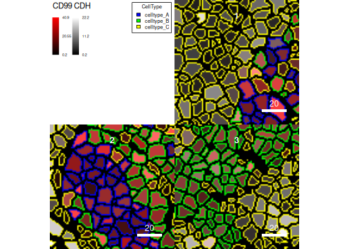

```r
plotCells(pancreasMasks, object = pancreasSCE,
            img_id = "ImageNb", cell_id = "CellNb",
            colour_by = c("CD99", "CDH"),
            outline_by = "CellType",
            colour = list(CD99 = c("black", "red"),
                        CDH = c("black", "white"),
                        CellType = c(celltype_A = "blue",
                                    celltype_B = "green",
                                    celltype_C = "yellow")))
```

# Customisation

The next sections explain different ways to customise the visual output of the `cytomapper` package. To find more details on additional parameters that can be set to customise the display, refer to `?'plotting-param'`.

## Subsetting the SingleCellExperiment object

The `cytomapper` package matches cells contained in the `SingleCellExperiment` to objects contained in the `CytoImageList` segmentation masks object via cell identifiers. These are integer values, which are unique to each object per image.

By matching these IDs, the user can subset the `SingleCellExperiment` object and therefore only visualize the cells retained in the object:

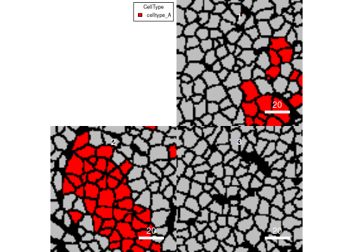

```r
cur_sce <- pancreasSCE[,colData(pancreasSCE)$CellType == "celltype_A"]
plotCells(pancreasMasks, object = cur_sce,
            img_id = "ImageNb", cell_id = "CellNb",
            colour_by = "CellType",
            colour = list(CellType = c(celltype_A = "red")))
```

This feature is also helpful when visualising individual images. By default, the legend will contain all metadata levels even those that are not contained in the selected image. By subsetting the `SingleCellExperiment` object to contain only the cells of the selected image, the legend will only contain the metadata levels of the selected cells.

## Background and missing colour

The background of a segemntation mask is defined by the value `0`. To change the background colour, the `background_colour` parameter can be set. Furthermore, cells that are not contained in the `SingleCellExperiment` object can be coloured by setting `missing_colour`. For an example, see figure @ref(fig:customization).

## Scale bar and image title

Depending on the cells’ and background colour, the scale bar and image title are not visible. To change the visual display of the scale bar, a named list can be passed to the `scale_bar` parameter. The list should contain one or multiple of the following entries: `length`, `label`, `cex`, `lwidth`, `colour`, `position`, `margin`, `frame`. For a detailed explanation on the individual entries, please refer to the `scale_bar` section in `?'plotting-param'`.

**Of note:** By default, the length of the scale bar is defined in number of pixels. Therefore, the user needs to know the length (e.g. in $\mu{m}$) to label the scale bar correctly.

The image titles can be set using the `image_title` parameter. Also here, the user needs to provide a named list with one or multiple of follwing entries: `text`, `position`, `colour`, `margin`, `font`, `cex`. The entry to `text` needs to be a character vector of the same length as the `CytoImageList` object.

Plotting of the scale bar and image title can be suppressed by setting the `scale_bar` and `image_title` parameters to `NULL`.

For an example, see figure @ref(fig:customization).

## Legend

By default, the legend all all its contents are adjusted to the size of the largest image in the `CytoImageList` object. However, legend features can be altered by setting the `legend` parameter. It takes a named list containing one or multiple of the follwoing entries: `colour_by.title.font`, `colour_by.title.cex`, `colour_by.labels.cex`, `colour_by.legend.cex`, `outline_by.title.font`, `outline_by.title.cex`, `outline_by.labels.cex`, `outline_by.legend.cex`, `margin`. For detailed explanation on the individual entries, please refer to the `legend` parameter in `?'plotting-param'`.

For an example, see figure @ref(fig:customization).

## Setting the margin between images

To enhance the display of individual images, the `cytomapper` package provides the `margin` parameter.

The `margin` parameter takes a single numeric indicating the gap (in pixels) between individual images.

For an example, see figure @ref(fig:customization).

## Scale the feature counts

By default, features are scaled to the minimum and maximum per channel. This behaviour facilitates visualization but does not allow the user to visually compare absolute expression counts across channels. The default behaviour can be suppressed by setting `scale = FALSE`.

In this case, counts are linearly scaled to the minimum and maximum across all channels and across all displayed images.

For an example, see figure @ref(fig:customization).

## Image interpolation

By default, colours are interpolated between pixels (see `?rasterImage` for details). To suppress this default behaviour, the user can set `interpolate = FALSE`.

## Thick borders

By setting `thick = TRUE`, the thickness of the outline border is increased. This setting can be useful to enhance the cell borders on large images.

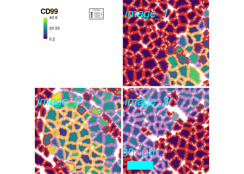

Plot customization example.

```r
plotCells(pancreasMasks, object = pancreasSCE,
            img_id = "ImageNb", cell_id = "CellNb",
            colour_by = "CD99",
            outline_by = "CellType",
            background_colour = "white",
            missing_colour = "black",
            scale_bar = list(length = 30,
                            label = expression("30 " ~ mu * "m"),
                            cex = 2,
                            lwidth = 10,
                            colour = "cyan",
                            position = "bottomleft",
                            margin = c(5,5),
                            frame = 3),
            image_title = list(text = c("image_1", "image_2", "image_3"),
                            position = "topleft",
                            colour = "cyan",
                            margin = c(2,10),
                            font = 3,
                            cex = 2),
            legend = list(colour_by.title.font = 2,
                            colour_by.title.cex = 1.2,
                            colour_by.labels.cex = 0.7,
                            outline_by.legend.cex = 0.3,
                            margin = 10),
            margin = 2,
            thick = TRUE)
```

# Returning plots and images

The user has the option to save the generated plots (see next section) or to get the plots and/or coloured images returned. If `return_plot` and/or `return_images` is set to `TRUE`, `cytomapper` returns a list object with one or two entries: `plot` and/or `images`.

The `display` parameter supports the entries `display = "all"` (default), which displays images in a grid-like fashion and `display = "single"`, which display images individually.

If the `return_plot` parameter is set to `TRUE`, `cytomapper` internally calls the `recordPlot` function and returns a plot object. The user can additionally set `display = "single"` to get a list of plots returned.

If the `return_images` parameter is set to `TRUE`, `cytomapper` returns a `SimpleList` object containing three-colour (red, green, blue) `Image` objects.

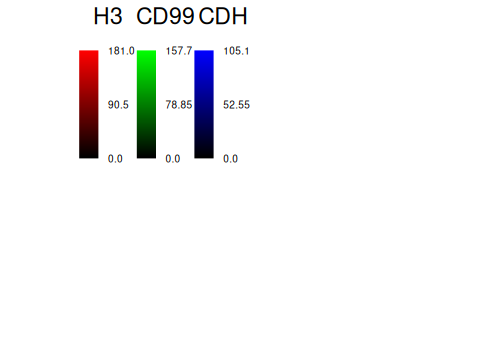

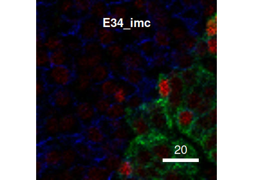

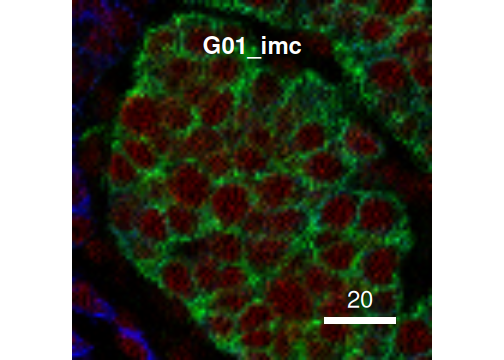

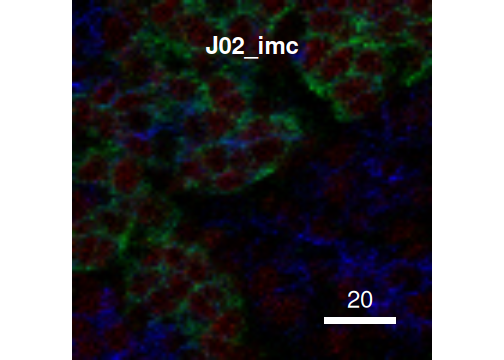

```r
cur_out <- plotPixels(pancreasImages, colour_by = c("H3", "CD99", "CDH"),
                return_plot = TRUE, return_images = TRUE,
                display = "single")
```

The returned plot objects now allows the plotting of individual images:

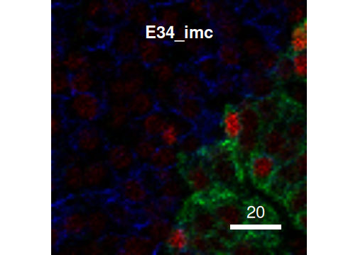

```r
cur_out$plot$E34_imc
```

Furthermore, the user can directly plot the coloured images from the returned `SimpleList` object:

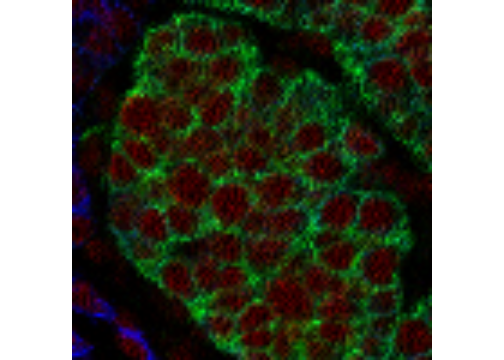

```r
plot(cur_out$images$G01_imc)
```

However, when plotting solely the coloured images, the image title and scale bar will be lost.

# Integration with ggplot2 objects

The [patchwork](https://patchwork.data-imaginist.com/) and [cowplot](https://cran.r-project.org/web/packages/cowplot/vignettes/introduction.html) R packages are popular frameworks to assemble full page figures consisting of multiple sub-panels. This section will highlight how to combine `cytomapper` plots and ggplot2 objects to create larger figures.

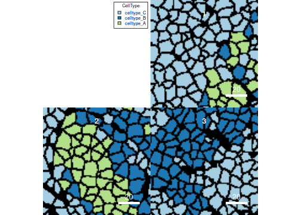

```r
library(cowplot)
library(ggplot2)

g1 <- ggplot(mtcars) + geom_point(aes(cyl, hp))
g2 <- plotCells(pancreasMasks, object = pancreasSCE,
            img_id = "ImageNb", cell_id = "CellNb",
            colour_by = "CellType", return_plot = TRUE)
```

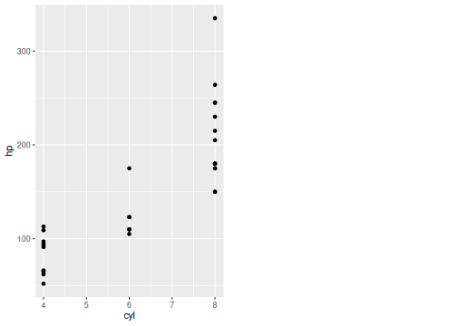

```r
g2 <- ggdraw(g2$plot, clip = "on")

plot_grid(g1, g2)
```

# Saving images

Finally, the user can save the plot by specifying `save_plot`. The `save_plot` entry takes a list of two entries: `filename` and `scale`. The `filename` should be a character representing a valid file name ending with `.png`, `.tiff` or `.jpeg`. The `scale` entry controls the resolution of the image (see `?"plotting-param"` for help). Increasing the scale parameter will increase the resolution of the final image.

When setting `display = "single"`, the `cytomapper` package will save individual images in individual files. The filename will be altered to the form `filename_x.png` where `x` is the position of the image in the `CytoImageList` object or `legend`.

# Gating cells on images

The `cytomapper` package provides the `cytomapperShiny` function to gate cells based on their expression values and visualizes selected cells on their corresponing images. This selection strategy can be useful if user-defined cell-type labels should be generated for cell-type classification. For details, please refer to the `?cytomapperShiny` manual or the `Help` button within the shiny application.

In brief, the `cytomapperShiny` function takes a `SingleCellExperiment` and (optionally) either a `CytoImageList` segmentation mask or a segmentation mask AND a `CytoImageList` multi-channel image object as input. The user needs to further provide an `img_id` and `cell_id` entry (see above).

The user can specify the number of plots (maximal 12 plot, maximal 2 marker per plot), select the individual images (specified in the `img_id` entry) and the different `assay` slots of the `SingleCellExperiment` object. Furthermore, for each plot, up to two markers can be selected for visualziation and gating. Gating is performed in a hierarchical fashion meaning that only the selected cells are displayed on the following plot. As an example: if the user selects certain cells in `Plot 1`, the expression values of only those cells are displayed in `Plot 2` and so on. If the user selects only one marker, the expression values are displayed as violin/beeswarm plots; if two markers are specified, expression values are displayed as scatter plots.

If the user provides a `CytoImageList` segmentation mask object, the `plotCells` function is called internally to visualize marker expression as well as the selected cells on the segmentation mask. Pixel-level information is diplayed if the user provides a `CytoImageList` multi-channel image object. In this setting, the user also needs to provide a segmentation mask object to outline the selected cells on the composite images.

As a final step, the user can download the selected cells in form of a `SingleCellExperiment` object. Furthermore, the user can specify a label for the current selection. The gates are stored in the `metadata(object)` entry. **Of note:** the metadata that was stored in the original object can be accessed via `metadata(object)$metadata`.

# Acknowledgements

We want to thank the [Bodenmiller laboratory](http://www.bodenmillerlab.org) for feedback on the package and its functionality. Special thanks goes to Daniel Schulz and Jana Fischer for testing the package.

# Contributions

Nicolas created the first version of `cytomapper` (named `IMCMapper`). Nils and Nicolas implemented and maintain the package. Nils and Tobias implemented and maintain the `cytomapperShiny` function.

# References

Angelo, Michael, Sean C. Bendall, Rachel Finck, Matthew B. Hale, Chuck Hitzman, Alexander D. Borowsky, Richard M. Levenson, et al. 2014. “Multiplexed Ion Beam Imaging of Human Breast Tumors.” *Nature Medicine* 20 (4): 436–42.

Carpenter, Anne E, Thouis R Jones, Michael R Lamprecht, Colin Clarke, In Han Kang, Ola Friman, David A Guertin, et al. 2006. “CellProfiler: Image Analysis Software for Identifying and Quantifying Cell Phenotypes.” *Genome Biology* 7: R100.

Damond, Nicolas, Stefanie Engler, Vito R. T. Zanotelli, Denis Schapiro, Clive H. Wasserfall, Irina Kusmartseva, Harry S. Nick, et al. 2019. “A Map of Human Type 1 Diabetes Progression by Imaging Mass Cytometry.” *Cell Metabolism* 29 (3): 755–768.e5.

Giesen, Charlotte, Hao A. O. Wang, Denis Schapiro, Nevena Zivanovic, Andrea Jacobs, Bodo Hattendorf, Peter J. Schüffler, et al. 2014. “Highly Multiplexed Imaging of Tumor Tissues with Subcellular Resolution by Mass Cytometry.” *Nature Methods* 11 (4): 417–22.

Gut, Gabriele, Markus D Herrmann, and Lucas Pelkmans. 2018. “Multiplexed Protein Maps Link Subcellular Organization to Cellular States.” *Science* 361: 1–13.

Lin, Jia-Ren, Benjamin Izar, Shu Wang, Clarence Yapp, Shaolin Mei, Parin M. Shah, Sandro Santagata, and Peter K. Sorger. 2018. “Highly Multiplexed Immunofluorescence Imaging of Human Tissues and Tumors Using t-CyCIF and Conventional Optical Microscopes.” *eLife* 7: 1–46.

Mavropoulos, Anastasia, Dongxia Lin, Ben Lam, Kuang-Jung Chang, Dwayne Bisgrove, and Olga Ornatsky. n.d. “Equivalence of Imaging Mass Cytometry and Immunofluorescence on FFPE Tissue Sections.”